# Student Grade Data analysis

Asif Shajahan B821240

26/05/2022

Installing the relevant libraries

```r
#install.packages("tidyverse")
library(tidyverse)
```

```r
library("ggplot2")
library(dplyr)
```

```r
#install.packages("dplyr")
```

Importing the dataset

```r
studentdata <- read.csv("Student Grade Prediction Dataset.csv")
```

### Question 2:Data Cleaning

```r
studentdata1 <- subset(studentdata,G3>0)
```

Creating derived variable for the average score across G1,G2 and G3.

```r
studentdata1$avgScore <-(studentdata1$G1+studentdata1$G2+studentdata1$G3)/3
```

Create another derived variable for the total score

```r
studentdata1$Tscore <- (studentdata1$G1+studentdata1$G2+studentdata1$G3)
```

###Question 3 ## Numerical and graphical summaries of all relevant variables

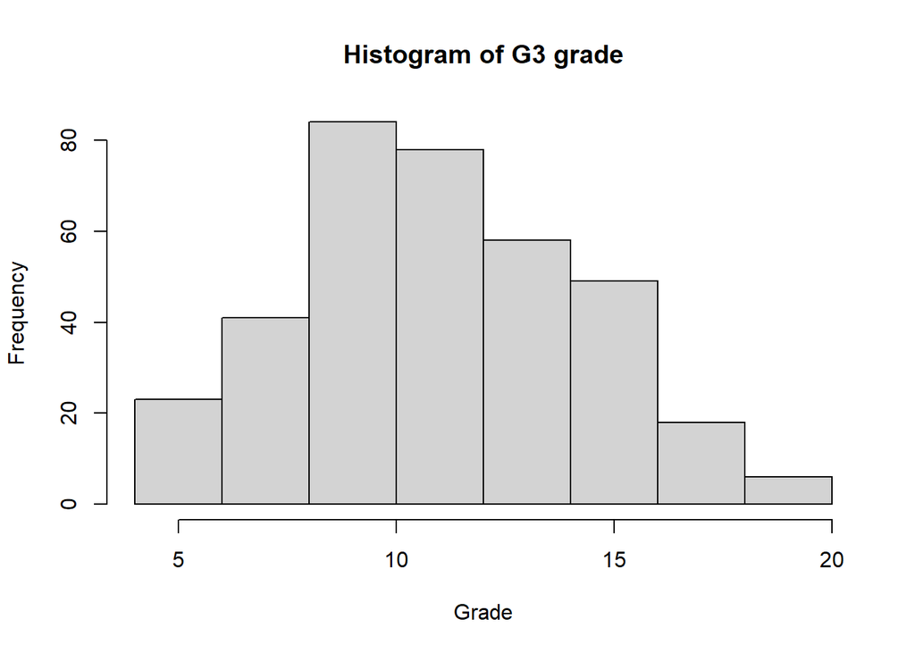

```r
hist(studentdata1$G3,main = "Histogram of G3 grade",xlab = "Grade")
```

```r
mean(studentdata1$G3)
```

```
## [1] 11.52381
```

The Average test score for student in Maths is 11.52381.

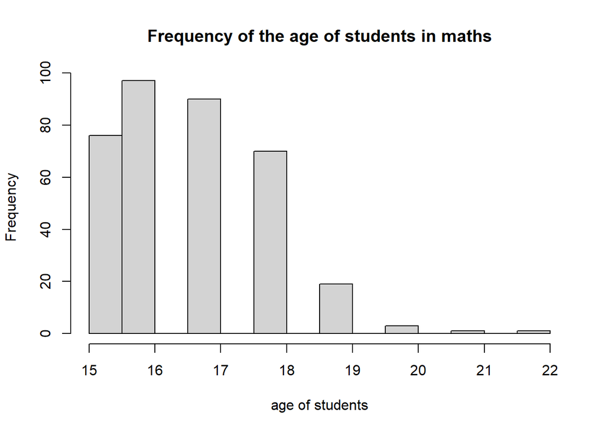

```r
hist(studentdata1$age,main = "Frequency of the age of students in maths",xlab = "age of students")
```

```r
c(mean(studentdata1$age))
```

```
## [1] 16.65546
```

The average age of students in both schools is around 17 years old. From the histogram above, there seems to be less older students in both schools.

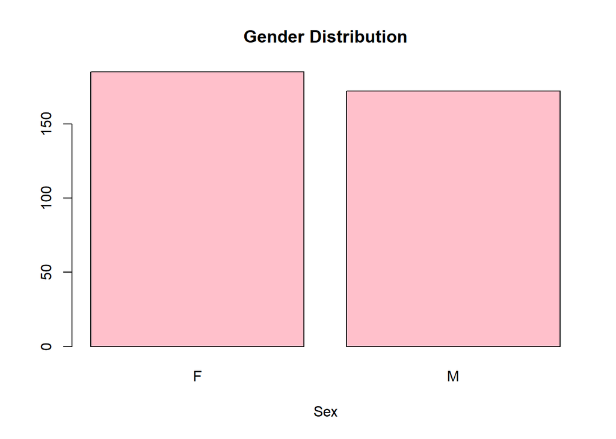

```r
gender = table(studentdata1$sex)
barplot(gender,main="Gender Distribution",xlab = "Sex",width = 2,col = "pink")
```

```r
table(gender)
```

```
## gender
## 172 185
##   1   1
```

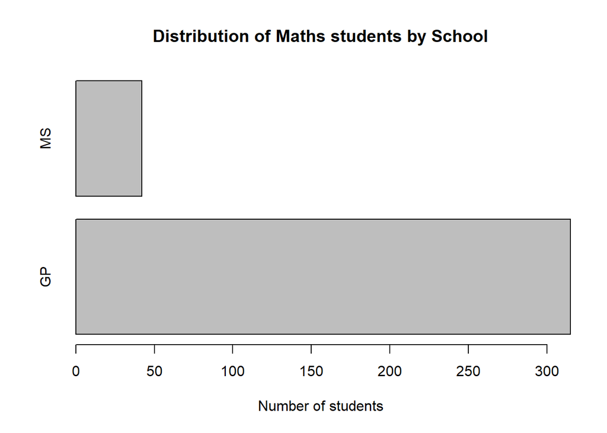

```r
schools <- table(studentdata1$school)
barplot(schools,main="Distribution of Maths students by School",xlab = "Number of students",width = 2,horiz = TRUE)
```

```r
table(gender)
```

```
## gender
## 172 185
##   1   1
```

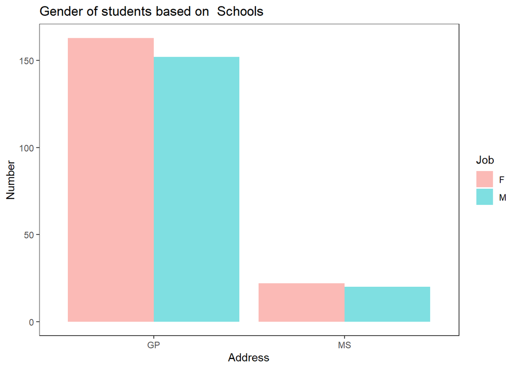

```r
studentdata1 %>%
  filter(studentdata1$school == "MS"|
           studentdata1$school == "GP") %>%
  ggplot(aes(studentdata1$school,fill=studentdata1$sex))+
  geom_bar(position = "dodge",alpha = 0.5)+
  theme_bw()+
  theme(panel.grid.major = element_blank(),
        panel.grid.minor = element_blank())+
  labs(title="Gender of students based on  Schools ",x = "Address",y="Number",fill=guide_legend(title="Job"))
```

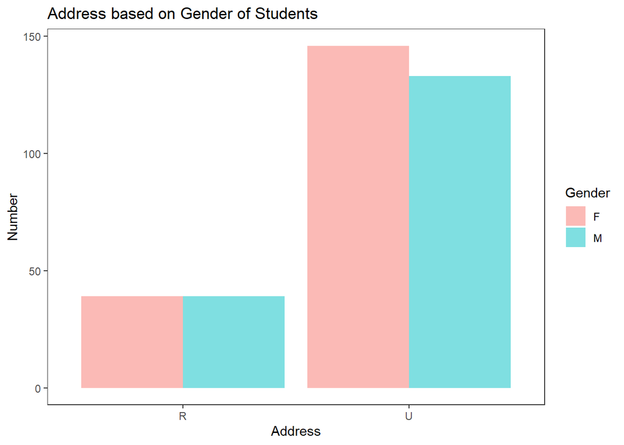

```r
studentdata1 %>%
  filter(studentdata1$address == "U"|
           studentdata1$address == "R") %>%
  ggplot(aes(studentdata1$address,fill=studentdata1$sex))+
  geom_bar(position = "dodge",alpha = 0.5)+
  theme_bw()+
  theme(panel.grid.major = element_blank(),
        panel.grid.minor = element_blank())+
  labs(title="Address based on Gender of Students",x = "Address",y="Number",fill=guide_legend(title="Gender"))
```

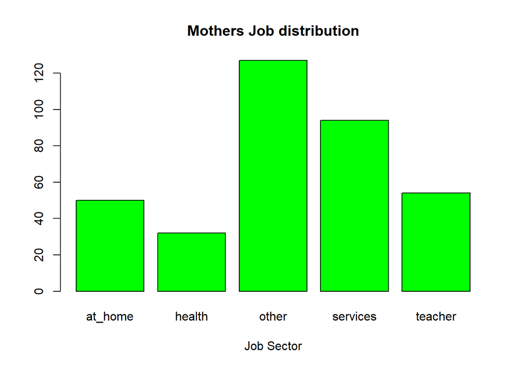

```r
MotherJ = table(studentdata1$Mjob)
barplot(MotherJ,main="Mothers Job distribution",xlab = "Job Sector",width = 1,col = "green")
```

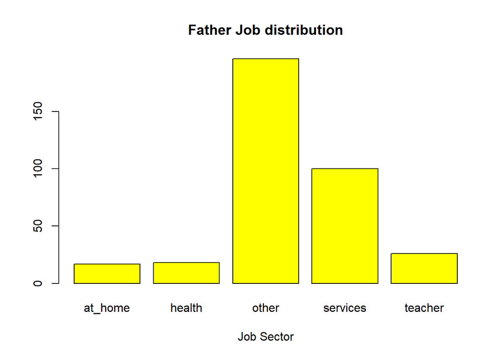

```r
## Fathers Job
FatherJ = table(studentdata1$Fjob)
barplot(FatherJ,main="Father Job distribution",xlab = "Job Sector",width = 1,col = ("yellow"))
```

Majority of the students parents work in the “other” job sector. Also, a higher number of mothers being in many of the other industries compared to fathers.

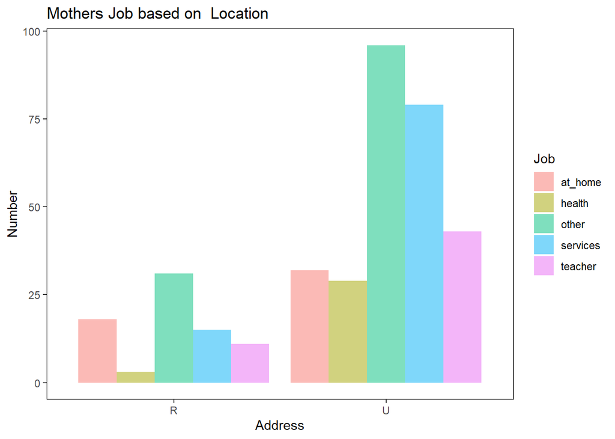

```r
studentdata1 %>%
  filter(studentdata1$address == "U"|
           studentdata1$address == "R") %>%
  ggplot(aes(studentdata1$address,fill=studentdata1$Mjob))+
  geom_bar(position = "dodge",alpha = 0.5)+
  theme_bw()+
  theme(panel.grid.major = element_blank(),
        panel.grid.minor = element_blank())+
  labs(title="Mothers Job based on  Location ",x = "Address",y="Number",fill=guide_legend(title="Job"))
```

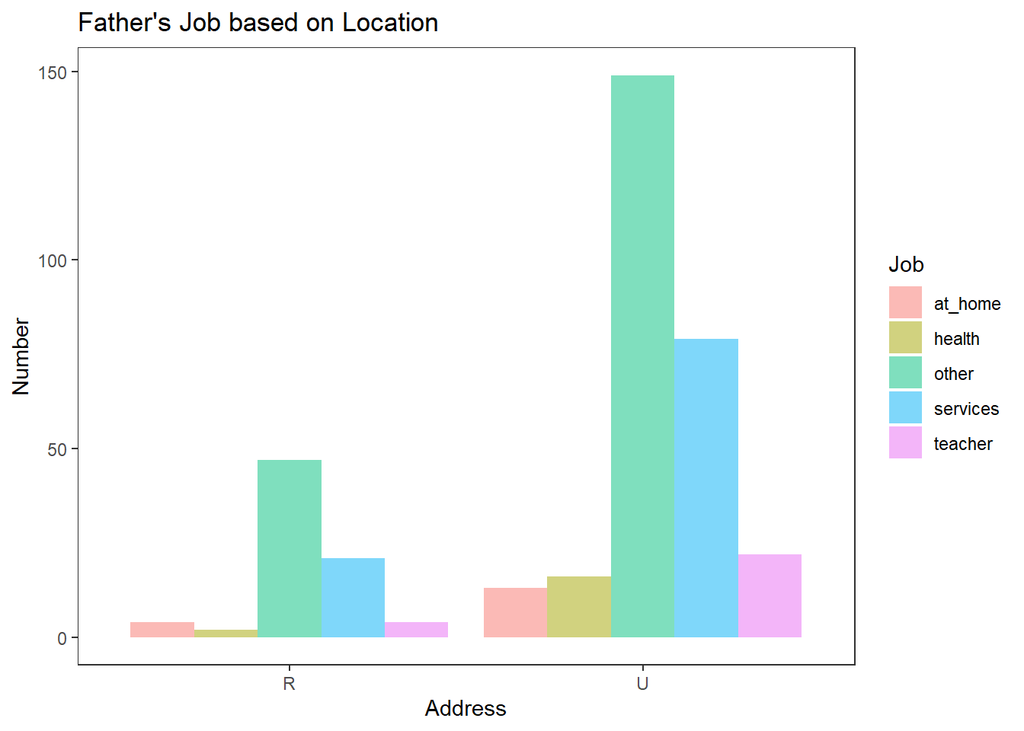

```r
studentdata1 %>%
  filter(studentdata1$address == "U"|
           studentdata1$address == "R") %>%
  ggplot(aes(studentdata1$address,fill=studentdata1$Fjob))+
  geom_bar(position = "dodge",alpha = 0.5)+
  theme_bw()+
  theme(panel.grid.major = element_blank(),
        panel.grid.minor = element_blank())+
  labs(title="Father's Job based on Location",x = "Address",y="Number",fill=guide_legend(title="Job"))
```

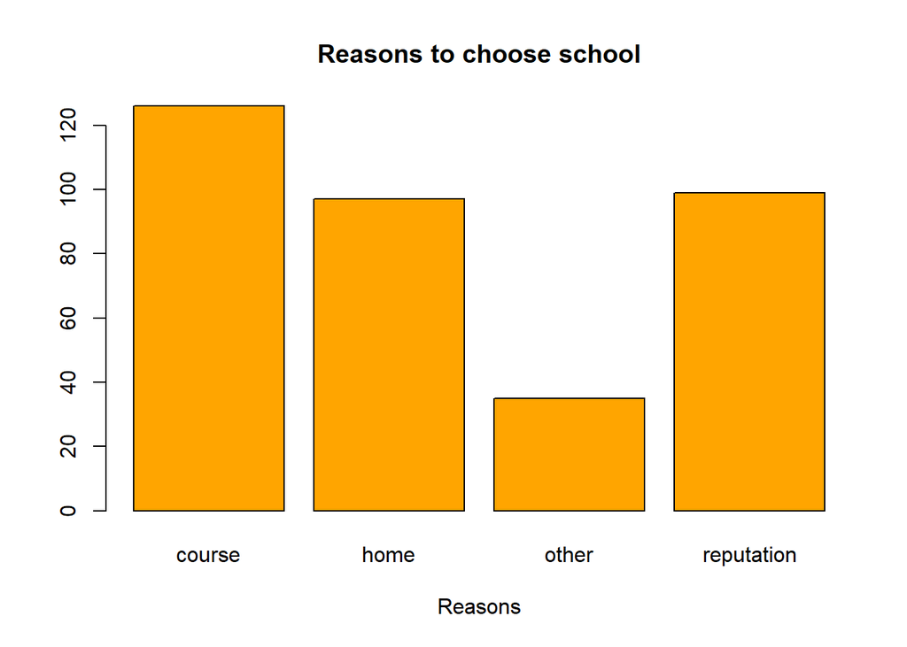

```r
ReasonS = table(studentdata1$reason)
barplot(ReasonS,main="Reasons to choose school",xlab = "Reasons",width = 1,col = "orange")
```

### Question 3B

##I) Relationship between absenses and marks scored

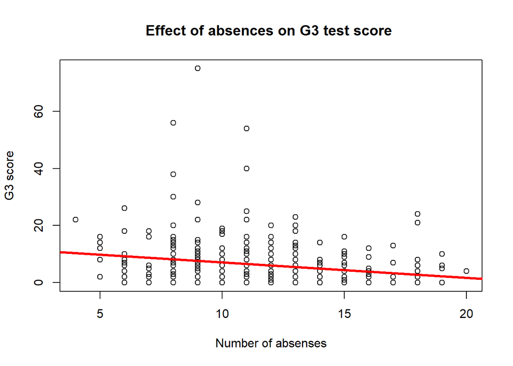

```r
score_absences = plot(studentdata1$G3, studentdata1$absences,main = "Effect of absences on G3 test score ",xlab = "Number of absenses",ylab = "G3 score")
abline(lm(studentdata1$absences ~ studentdata1$G3), col = "red", lwd = 3)
```

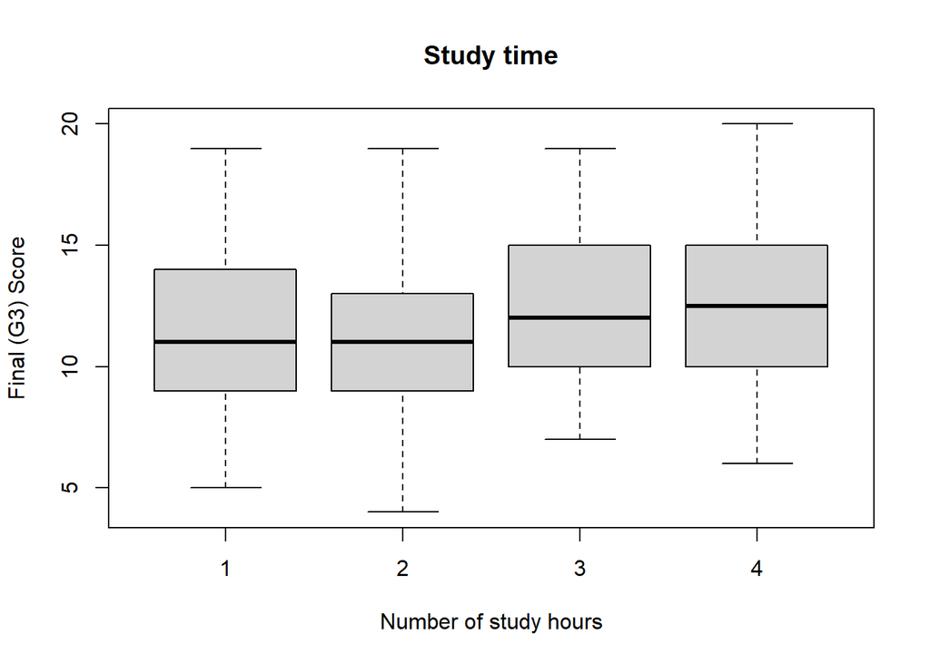

```r
boxplot(studentdata1$G3 ~ studentdata1$studytime,main = "Study time",xlab = "Number of study hours",ylab = "Final (G3) Score")
```

## II) Relationship between Grade distribution and Gender.

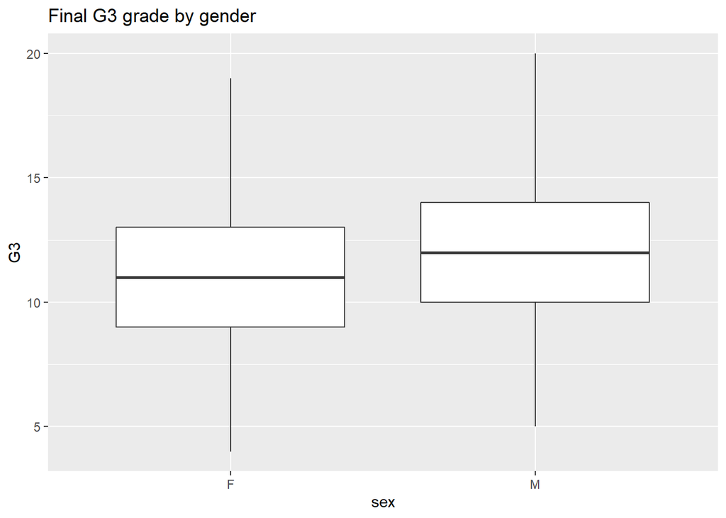

```r
ggplot(studentdata1,aes(sex,y = G3)) +
  geom_boxplot(aes9fill = studentdata1$sex) +
  ggtitle("Final G3 grade by gender")
```

Male students tend to have a higher average G3 score than female students. To make this observation more thorough, t-test could be used to determine the difference in G3 grade of both genders.

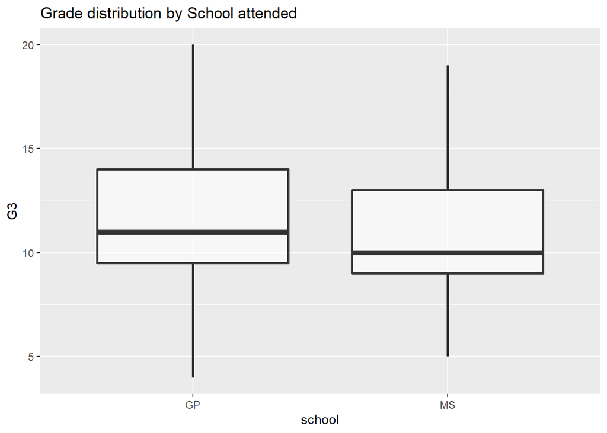

```r
studentdata1$school=factor(studentdata1$school)
ggplot(studentdata1, aes(x=school,y=G3))+
  geom_boxplot(aes(fill = Medu),alpha = .6,size = 1)+
  ggtitle("Grade distribution by School attended")
```

The boxplot shows that Gabriel Pereira (GP) has a higher average G3 score compared to Mousinho da Silveira

## IV) A count variable and a factor.

### Absences based on romantic relationship.

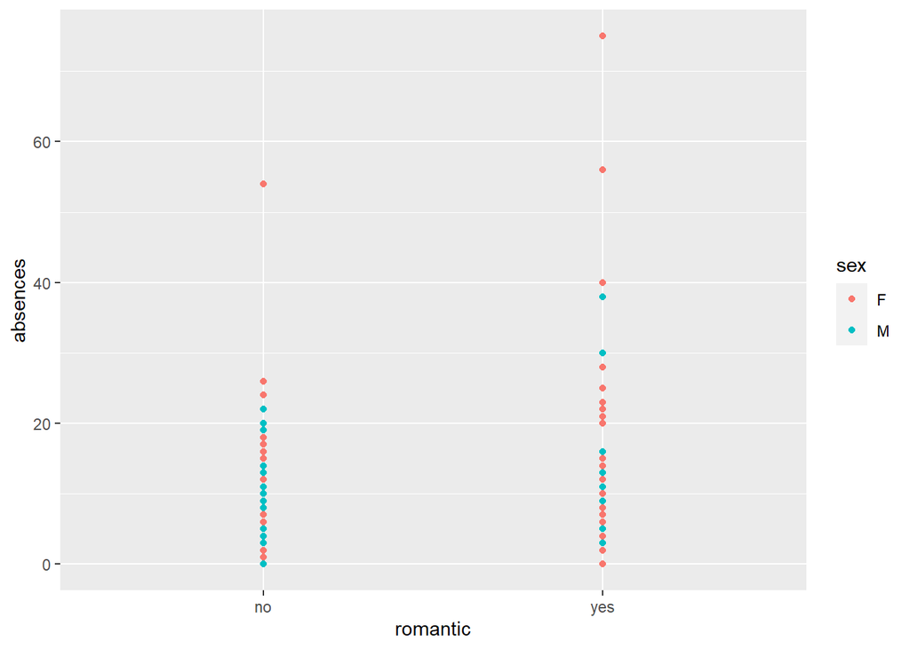

```r
ggplot(studentdata1,aes(x = romantic , y = absences))+
  geom_point(aes(color = sex))+
  stat_smooth(method = "lm",
              col = "red")
```

This plot shows that students being in a relationship tend to have higher number of absences.

## V)

### Education levels of both parents effect on grade score

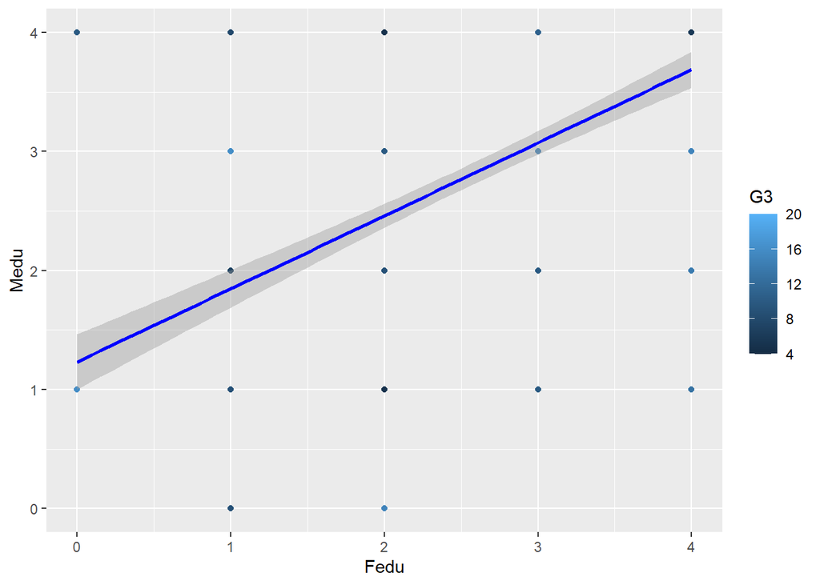

```r
Edulevel <- ggplot(studentdata1,aes(x = Fedu,y = Medu))+
  geom_point(aes(color = G3))+
  stat_smooth(col = "blue",method = "lm")
Edulevel
```

## 3C

A relevant subset is to choose one of the two schools that the student attends.In this case, Gabriel Pereira (GP) will be relevant as there are more students attending this school

## 3d

## 3e

### Normal Linear Model.

####Fitting the model The Aim of the linear model is to predict the final (G3) score. Let’s start to construct a scatter diagram of the G3 score

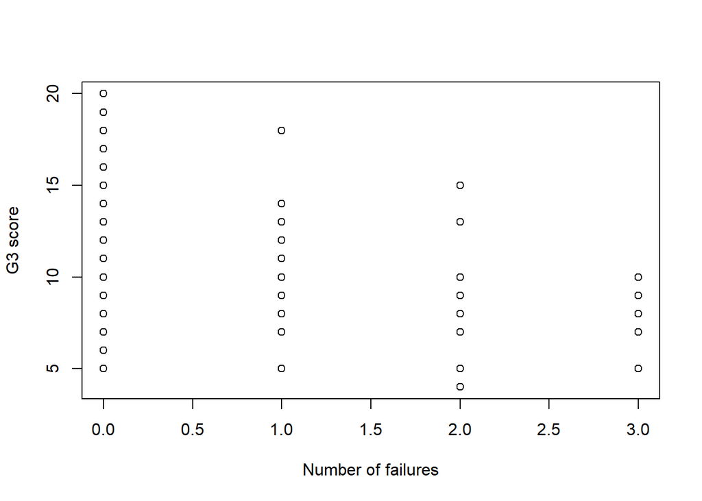

```r
studentdata1$school <- as.factor(studentdata1$school)
plot(studentdata1$failures, studentdata1$G3,xlab = "Number of failures",ylab = "G3 score")
```

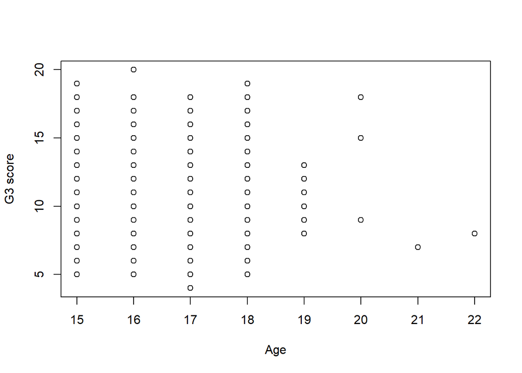

```r
plot(studentdata1$age, studentdata1$G3,xlab = "Age",ylab = "G3 score")
```

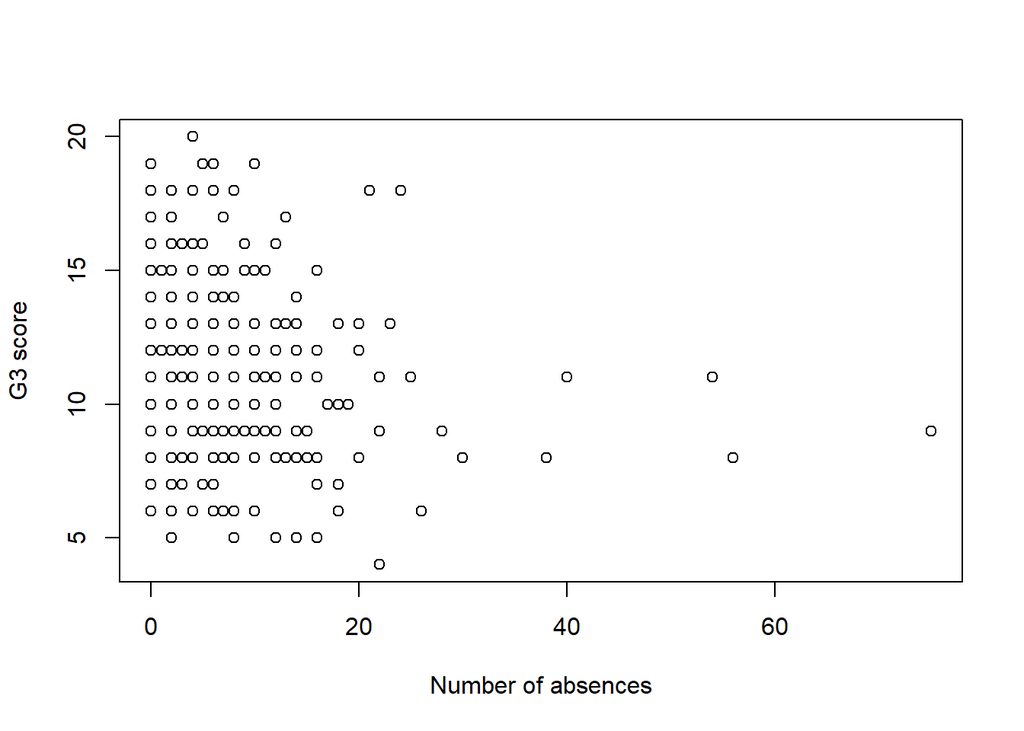

```r
plot(studentdata1$absences, studentdata1$G3,xlab = "Number of absences",ylab = "G3 score")
```

For the linear model, we will use 3 predictors to predict the students final grade. The predictors are: - Past class failures - Age - Absences

```r
 linmod1<- glm(G3~failures + age + absences,family="gaussian",data = studentdata1)
summary(linmod1)
```

```
##
## Call:
## glm(formula = G3 ~ failures + age + absences, family = "gaussian",
##     data = studentdata1)
##
## Deviance Residuals:
##     Min       1Q   Median       3Q      Max
## -6.5443  -2.0721  -0.2804   2.2115   8.5817
##
## Coefficients:
##             Estimate Std. Error t value Pr(>|t|)
## (Intercept) 13.70737    2.21100   6.200 1.58e-09 ***
## failures    -1.24869    0.25090  -4.977 1.01e-06 ***
## age         -0.08571    0.13459  -0.637  0.52463
## absences    -0.06597    0.02029  -3.252  0.00126 **
## ---
## Signif. codes:  0 '***' 0.001 '**' 0.01 '*' 0.05 '.' 0.1 ' ' 1
##
## (Dispersion parameter for gaussian family taken to be 9.280501)
##
##     Null deviance: 3709  on 356  degrees of freedom
## Residual deviance: 3276  on 353  degrees of freedom
## AIC: 1814.5
##
## Number of Fisher Scoring iterations: 2
```

From this, we get the best estimate of the trendline which we call the regression line. The coefficients have been determined for the 3 predictors, hence

G3 ~ Normal(13.70737 -1.24869 x failures - 0.08571 x age - 0.06597 x absences,3.04639147189)

To check the suitability of this model, we start to look at the residuals against each of the predictors to make sure the spread of data points looks even and regular across the plot.

#### Evaluating the Model

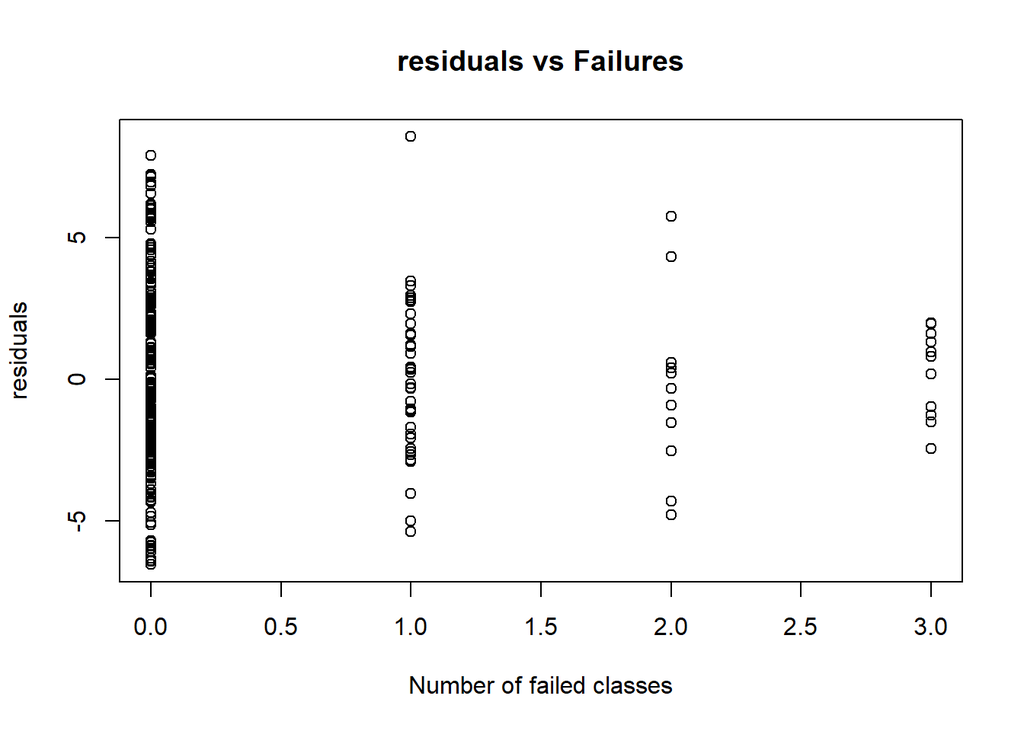

```r
plot(studentdata1$failures,linmod1$residuals,main = "residuals vs Failures",xlab = "Number of failed classes",ylab = "residuals")
```

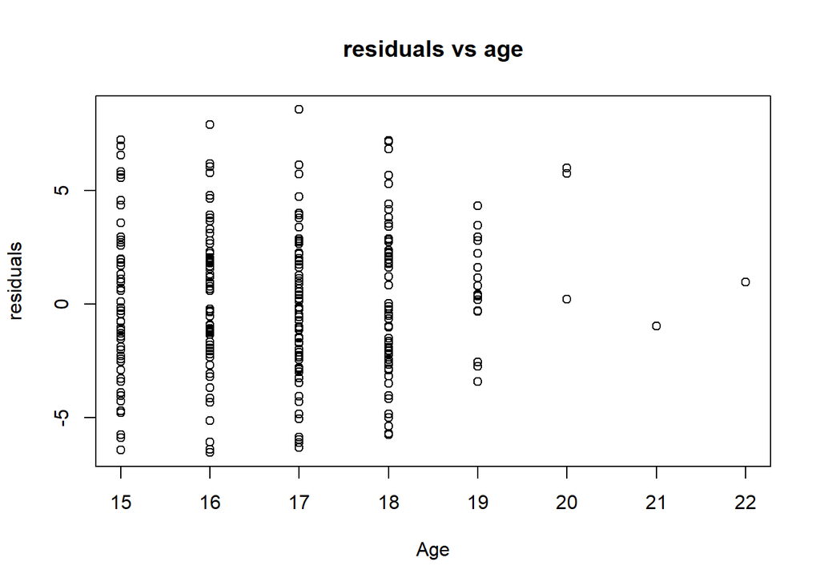

```r
plot(studentdata1$age,linmod1$residuals,main = "residuals vs age",xlab = "Age",ylab = "residuals")
```

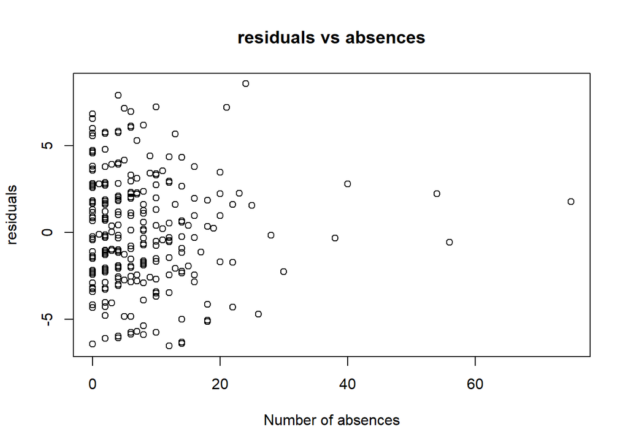

```r
plot(studentdata1$absences,linmod1$residuals,main = "residuals vs absences",xlab = "Number of absences",ylab = "residuals")
```

From the residual graphs, we construct a histogram of the residuals.We should expect a Gaussian curve.

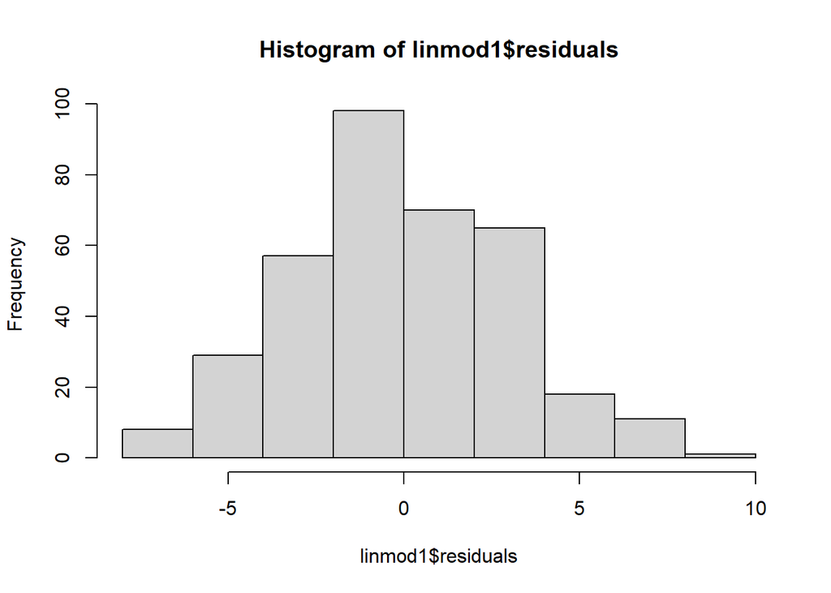

```r
hist(linmod1$residuals)
```

This means that the choice of “gaussian” distribution is suitable and so we construct a Q-Q plot.

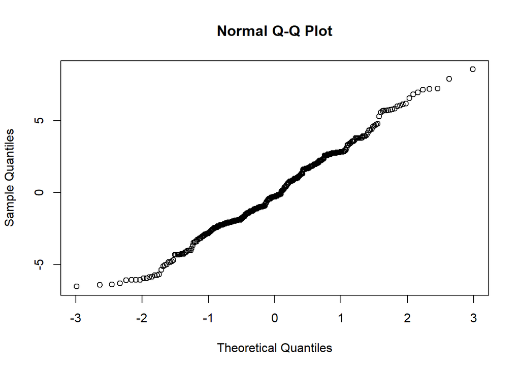

```r
qqnorm(linmod1$residuals)
```

Apart from a few points on the ends points of the q-q plot. The observed distribution looks appropriate and the final model can be written as

G3 ~ Normal(13.70737 -1.24869 x failures - 0.08571 x age - 0.06597 x absences,3.04639147189)

```r
confint(linmod1)
```

```
##                  2.5 %      97.5 %
## (Intercept)  9.3738835 18.04085478
## failures    -1.7404378 -0.75693321
## age         -0.3494987  0.17807403
## absences    -0.1057325 -0.02620792
```

## Poisson model

```r
studentdata1$school<- as.factor(studentdata1$school)
as_tibble(studentdata1)
```

```
## # A tibble: 357 x 35
##    school sex     age address famsize Pstatus  Medu  Fedu Mjob     Fjob   reason
##    <fct>  <chr> <int> <chr>   <chr>   <chr>   <int> <int> <chr>    <chr>  <chr>
##  1 GP     F        18 U       GT3     A           4     4 at_home  teach~ course
##  2 GP     F        17 U       GT3     T           1     1 at_home  other  course
##  3 GP     F        15 U       LE3     T           1     1 at_home  other  other
##  4 GP     F        15 U       GT3     T           4     2 health   servi~ home
##  5 GP     F        16 U       GT3     T           3     3 other    other  home
##  6 GP     M        16 U       LE3     T           4     3 services other  reput~
##  7 GP     M        16 U       LE3     T           2     2 other    other  home
##  8 GP     F        17 U       GT3     A           4     4 other    teach~ home
##  9 GP     M        15 U       LE3     A           3     2 services other  home
## 10 GP     M        15 U       GT3     T           3     4 other    other  home
## # ... with 347 more rows, and 24 more variables: guardian <chr>,
## #   traveltime <int>, studytime <int>, failures <int>, schoolsup <chr>,
## #   famsup <chr>, paid <chr>, activities <chr>, nursery <chr>, higher <chr>,
## #   internet <chr>, romantic <chr>, famrel <int>, freetime <int>, goout <int>,
## #   Dalc <int>, Walc <int>, health <int>, absences <int>, G1 <int>, G2 <int>,
## #   G3 <int>, avgScore <dbl>, Tscore <int>
```

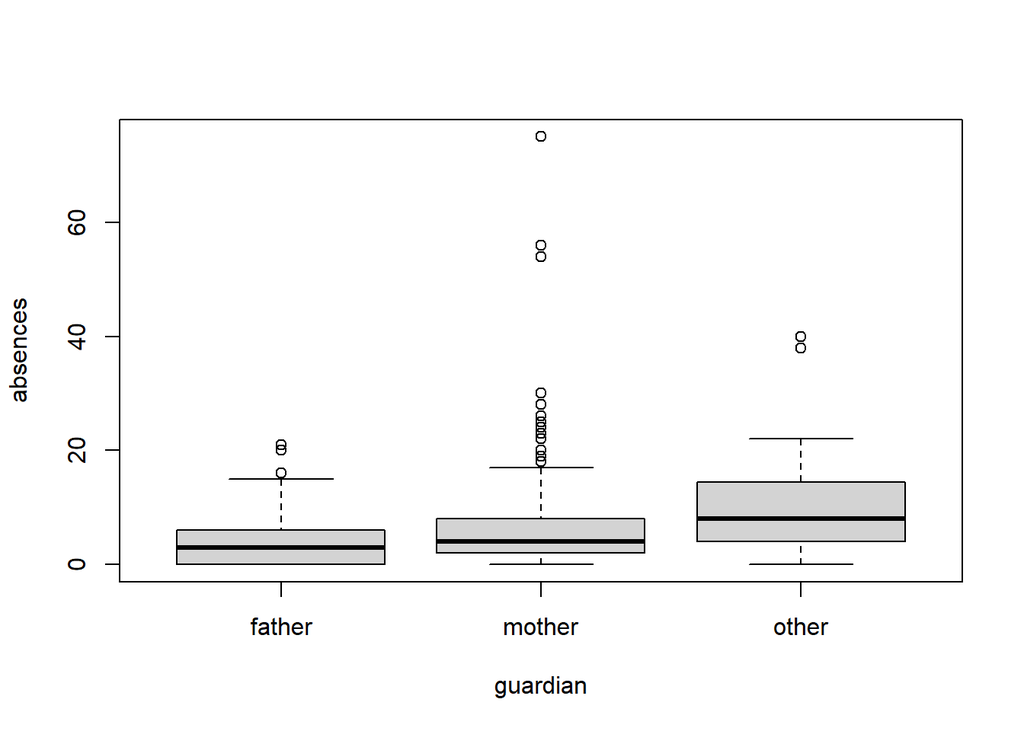

```r
boxplot(studentdata1$absences~studentdata1$guardian,xlab = "guardian",ylab = "absences")
```

This is a typical poisson distribution as the variables are clustered near zero with long “tails” into higher numbers.

[figure not shown]

```r
hist(studentdata1[studentdata1$guardian == "father",]$absences,main = " students living in Urban area",xlab ="number of absences",col = "red")
```

## Logistic Model

Predict if a student attended nursery based on gender,family size,mothers education,fathers education and cohabitation status.

To start this logistic model, we must first assign binary variables to the nursery variable Assign 0 for didn’t attend nursery 1 for attend nursery

```r
#create new variable Bnursery
studentdata1$Bnursery[studentdata1$nursery == "no"]<- 0
studentdata1$Bnursery[studentdata1$nursery == "yes"]<- 1


nursery.mod <- glm(studentdata1$Bnursery ~ sex + famsize + Medu + Fedu + Pstatus, family = binomial, data =studentdata1)
```

We use the summary function to see which of the predictors significantly predict whether or not a student attended nursery.

```r
summary(nursery.mod)
```

```
##
## Call:
## glm(formula = studentdata1$Bnursery ~ sex + famsize + Medu +
##     Fedu + Pstatus, family = binomial, data = studentdata1)
##
## Deviance Residuals:
##     Min       1Q   Median       3Q      Max
## -2.3396   0.3191   0.5494   0.7059   1.2478
##
## Coefficients:
##             Estimate Std. Error z value Pr(>|z|)
## (Intercept)   0.6334     0.7450   0.850   0.3952
## sexM         -0.2977     0.2778  -1.072   0.2839
## famsizeLE3    0.8670     0.3455   2.509   0.0121 *
## Medu          0.3064     0.1556   1.969   0.0490 *
## Fedu          0.2619     0.1621   1.615   0.1062
## PstatusT     -0.8061     0.6323  -1.275   0.2024
## ---
## Signif. codes:  0 '***' 0.001 '**' 0.01 '*' 0.05 '.' 0.1 ' ' 1
##
## (Dispersion parameter for binomial family taken to be 1)
##
##     Null deviance: 356.18  on 356  degrees of freedom
## Residual deviance: 329.44  on 351  degrees of freedom
## AIC: 341.44
##
## Number of Fisher Scoring iterations: 5
```

### 3G